# lab7

#### Read and normalize the counts table given in [this](http://afodor.github.io/classes/stats2015/longitdunalRNASeqData.zip) RNA seq dataset of *E. Coli* genes from mice.

Read data from disk and view a summary of its contents.

```r
rawCounts <- read.table("data/nc101_scaff_dataCounts.txt", sep="\t", header=TRUE, row.names=1)
head(rawCounts)
```

|  | D2_01 | D2_02 | D2_03 | W12_01 | W12_02 | W12_03 | w20_01 | w20_02 | w20_03 | w20_04 | w20_05 |
| --- | --- | --- | --- | --- | --- | --- | --- | --- | --- | --- | --- |
| NC101_00003 | 329 | 29 | 40 | 97 | 423 | 141 | 469 | 342 | 884 | 713 | 52 |
| NC101_00004 | 30 | 2 | 6 | 7 | 83 | 34 | 76 | 45 | 131 | 127 | 65 |
| NC101_00005 | 145 | 53 | 23 | 122 | 271 | 128 | 102 | 57 | 134 | 112 | 13 |
| NC101_00006 | 510 | 80 | 54 | 156 | 717 | 193 | 489 | 228 | 536 | 487 | 57 |
| NC101_00007 | 5 | 3 | 0 | 13 | 25 | 1 | 9 | 2 | 30 | 9 | 11 |
| NC101_00008 | 14 | 4 | 2 | 8 | 65 | 14 | 208 | 82 | 302 | 241 | 14 |

The first 3 columns represent samples from “day 2 (before the mice have inflammation symptoms), the next 3 from “week 12” (inflammation onset), and the last 5 from “week 20” (cancer onset).

Remove rare genes (defined as those having a count median of less than 5).

```r
nonRareCounts <- rawCounts[apply(rawCounts, 1, median) > 5,]
```

Normalize by determining relative counts to correct for sequencing depth.

```r
normalizedCounts <- nonRareCounts
for (i in 1:ncol(nonRareCounts))
{
    colSum <- sum(nonRareCounts[,i])
    normalizedCounts[,i] <- nonRareCounts[,i]/colSum
}
head(normalizedCounts)
```

|  | D2_01 | D2_02 | D2_03 | W12_01 | W12_02 | W12_03 | w20_01 | w20_02 | w20_03 | w20_04 | w20_05 |
| --- | --- | --- | --- | --- | --- | --- | --- | --- | --- | --- | --- |
| NC101_00003 | 5.680896e-04 | 1.838224e-04 | 5.226435e-04 | 3.748604e-04 | 3.906539e-04 | 3.327968e-04 | 3.955886e-04 | 4.990602e-04 | 5.194085e-04 | 4.562896e-04 | 7.653778e-05 |
| NC101_00004 | 5.180148e-05 | 1.267740e-05 | 7.839653e-05 | 2.705178e-05 | 7.665312e-05 | 8.024887e-05 | 6.410392e-05 | 6.566582e-05 | 7.697117e-05 | 8.127459e-05 | 9.567223e-05 |
| NC101_00005 | 2.503738e-04 | 3.359512e-04 | 3.005200e-04 | 4.714739e-04 | 2.502771e-04 | 3.021134e-04 | 8.603420e-05 | 8.317671e-05 | 7.873387e-05 | 7.167523e-05 | 1.913445e-05 |
| NC101_00006 | 8.806252e-04 | 5.070962e-04 | 7.055688e-04 | 6.028683e-04 | 6.621721e-04 | 4.555303e-04 | 4.124581e-04 | 3.327068e-04 | 3.149355e-04 | 3.116593e-04 | 8.389719e-05 |
| NC101_00007 | 8.633580e-06 | 1.901611e-05 | 0.000000e+00 | 5.023902e-05 | 2.308829e-05 | 2.360261e-06 | 7.591253e-06 | 2.918481e-06 | 1.762698e-05 | 5.759617e-06 | 1.619069e-05 |
| NC101_00008 | 2.417403e-05 | 2.535481e-05 | 2.613218e-05 | 3.091632e-05 | 6.002955e-05 | 3.304365e-05 | 1.754423e-04 | 1.196577e-04 | 1.774450e-04 | 1.542297e-04 | 2.060633e-05 |

#### Generate linear models with differing parameter configurations and save the respective p-values.

Define and initialize vectors in which to store the resultant p-values.

```r
pValuesOneWayAnova <- vector()
pValuesRegression <- vector()
pValueModelDiff <- vector()
```

Define sample days and their labels.

```r
sampleDays <- c(rep(2, 3), rep(12 * 7, 3), rep(20 * 7 , 5))
sampleLabels <- factor(c(rep("day2", 3), rep("week12", 3), rep("week20", 5)))
```

Perform ANOVAs and save the resulting p-values.

```r
for (i in 1:nrow(normalizedCounts)) {
    row <- as.numeric(normalizedCounts[i,])
    # (A) Perform a one-way ANOVA with categories “day 2”, “week 12”, and “week 20”.
    pValuesOneWayAnova[i] <- anova(lm(row ~ sampleLabels))$"Pr(>F)"[1]
    # (B) Perform an ANOVA as a linear regression as a function of time.
    pValuesRegression[i] <- anova(lm(row ~ sampleDays))$"Pr(>F)"[1]
    # (C) Perform an ANVOA comparing the three-parameter model from (A) and the two parameter model from (B).
    pValueModelDiff[i] <- anova(lm(row ~ sampleDays*sampleLabels))$"Pr(>F)"[2]
}
```

#### Plot out the histogram of all p-values.

Histogram for the p-values of three-parameter ANOVAs based on the categories “day 2”, “week 12”, and “week 20”.

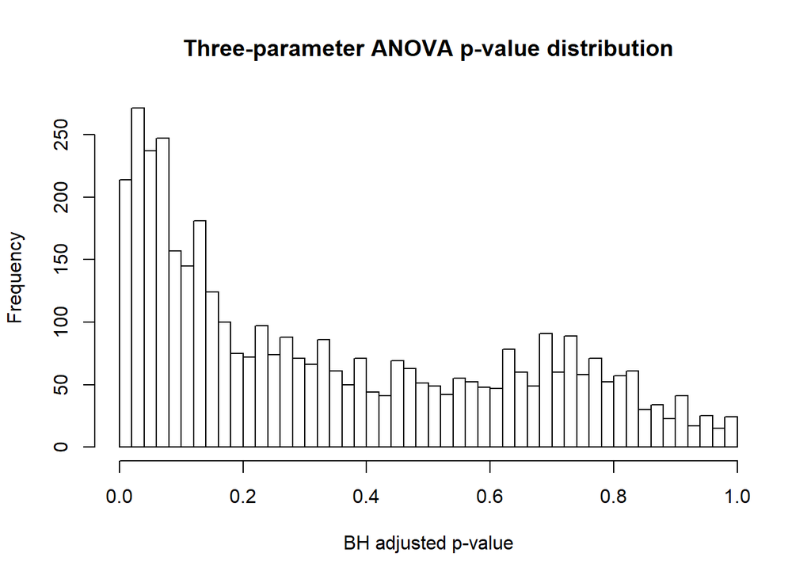

```r
hist(p.adjust(pValuesOneWayAnova, method="BH"),
     breaks=50,
     main="Three-parameter ANOVA p-value distribution",
     xlab="BH adjusted p-value")
```

- Based on the above graph, **612** genes are significantly different between sampling times at a BH corrected p-value threshold of 0.05.

Histogram for the p-values of two-parameter ANOVAs using linear regression dependent on time.

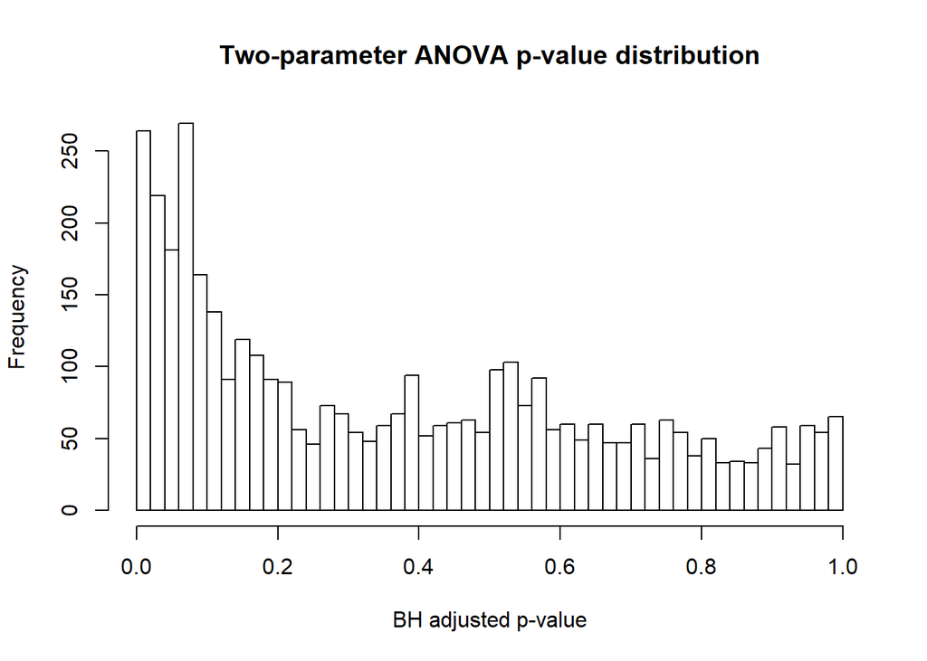

```r
hist(p.adjust(pValuesRegression, method="BH"),
     breaks=50,
     main="Two-parameter ANOVA p-value distribution",
     xlab="BH adjusted p-value")
```

- Based on the above graph, **581** genes are significantly different between sampling times (the regression slope is not 0) at a BH corrected p-value threshold of 0.05.

Histogram of p-values from ANOVAs comparing the two-parameter model to the three-parameter model.

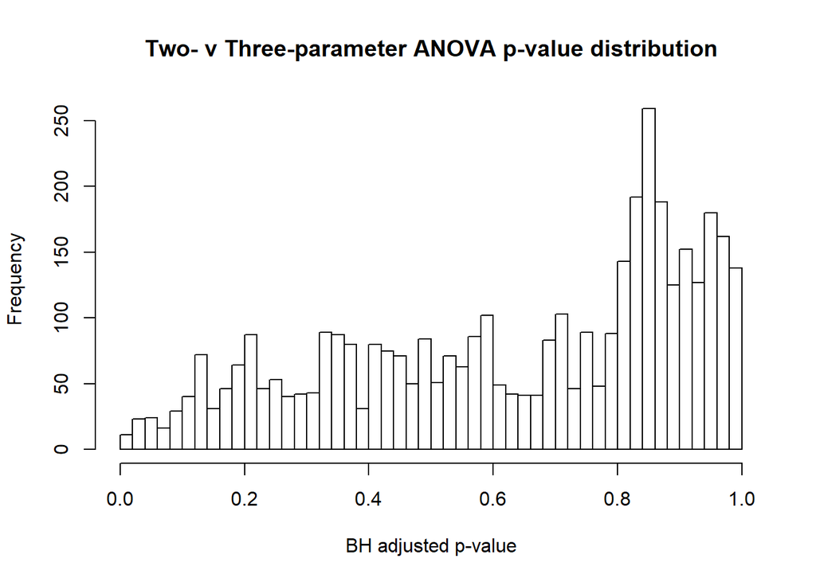

```r
hist(p.adjust(pValueModelDiff, method="BH"),
     breaks=50,
     main="Two- v Three-parameter ANOVA p-value distribution",
     xlab="BH adjusted p-value")
```

- Based on the above graph, **39** genes have different associated two- and three-parameter models at a BH corrected p-value threshold of 0.05.

#### Plot the relative abundance of the most significant gene under each of the three ANOVA models.

Create a dataframe containing the p-values from each of the three ANOVA models.

```r
index <- 1:length(pValuesOneWayAnova)
pval.df <- data.frame(index, pValuesOneWayAnova, pValuesRegression, pValueModelDiff)
```

A boxplot showing the most significant gene under the 3-parameter ANOVA model.

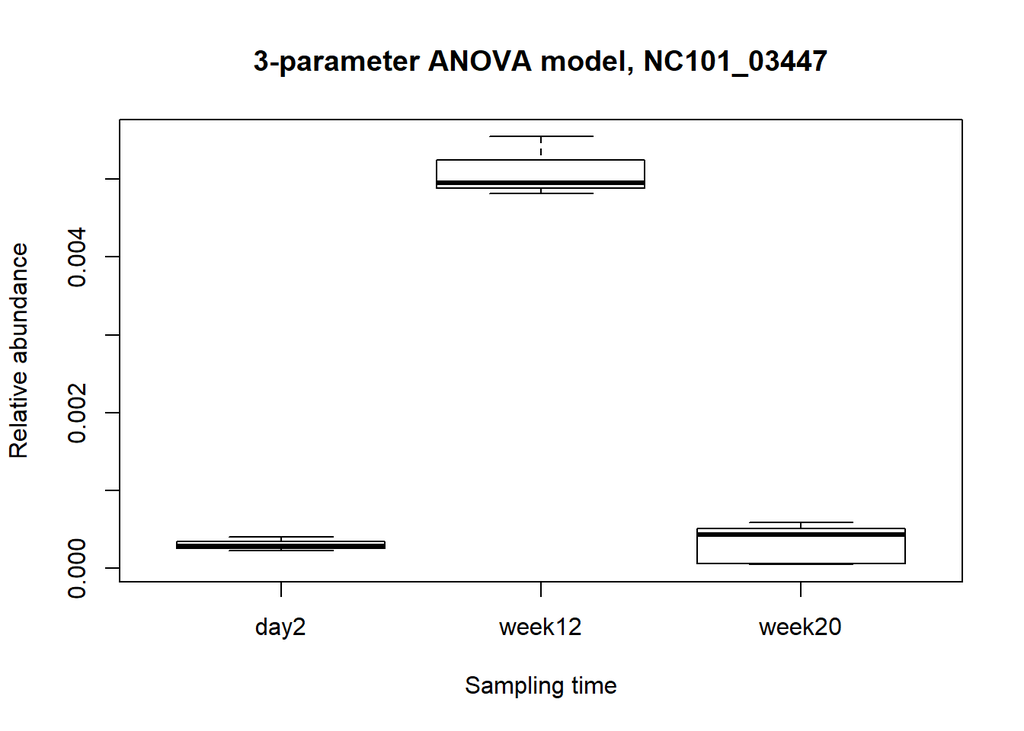

```r
pval.df.3pSorted <- pval.df[order(pval.df$pValuesOneWayAnova),]
row <- normalizedCounts[pval.df.3pSorted$index[1],]
gene <- rownames(row)
boxplot(as.numeric(row) ~ sampleLabels,
        main=paste("3-parameter ANOVA model,", gene),
        ylab="Relative abundance",
        xlab="Sampling time")
```

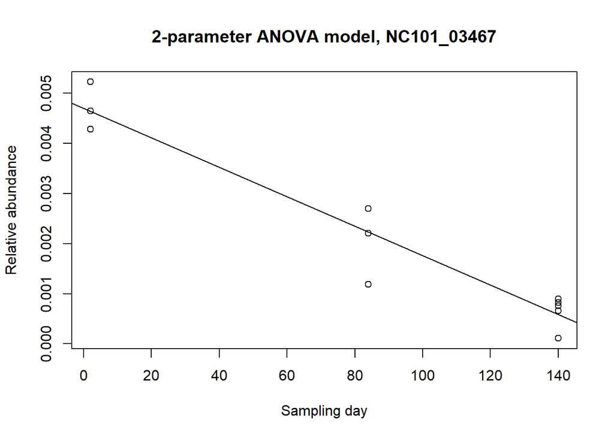

```r
pval.df.2pSorted <- pval.df[order(pval.df$pValuesRegression),]
row <- normalizedCounts[pval.df.2pSorted$index[1],]
gene <- rownames(row)
plot(as.numeric(row) ~ sampleDays,
        main=paste("2-parameter ANOVA model,", gene),
        ylab="Relative abundance",
        xlab="Sampling day")
abline(lm(as.numeric(row) ~ sampleDays))
```

A boxplot showing the most significant gene under the ANOVA comparing the full 3-parameter model and the reduced 2-parameter model.

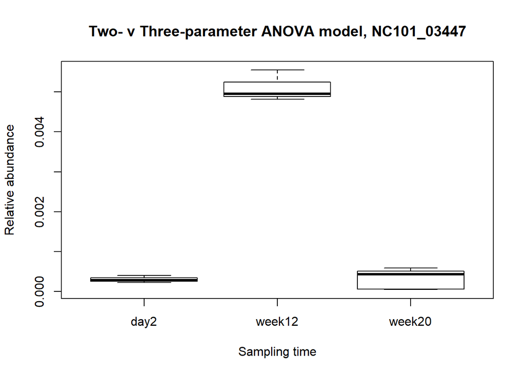

```r
pval.df.diffSorted <- pval.df[order(pval.df$pValueModelDiff),]
row <- normalizedCounts[pval.df.diffSorted$index[1],]
gene <- rownames(row)
boxplot(as.numeric(row) ~ sampleLabels,
        main=paste("Two- v Three-parameter ANOVA model,", gene),
        ylab="Relative abundance",
        xlab="Sampling time")
```

#### Choose a model.

Given that a similar number of genes can be represented using either a 3-parameter model or a 2-parameter model, but that only a relatively small portion of 3-parameter models are statistically different from their 2-parameter counterparts, I would argue that the 2-parameter model is more appropriate for these data.